# Weather forecasting

Authors: Piotr Pigoń, Aleksandra Pestka

This script enables the user to forecast monthly average temperature,wind force,precipitation etc. benefiting by provided weather dataset. The chosen method is **ARIMA - Autoregressive integrated moving average**. Model requires three parameters **(p,d,q)** and is traditionally configured manually:

*'p'* is the order (number of time lags) of the autoregressive model)  
*'d'* is the degree of differencing (the number of times the data have had past values subtracted)  
*'q'* is the order of the moving-average model

The following data are findings from website: dane.imgw.pl (monthly open-source datasets for KRAKÓW-OBSERWATORIUM)

With this script we would like to forecast monthly temperature basing on datasets within the latest 11 full years (Jan 2007- Dec 2017).

Firstly, we will import needful files (with prepared auctorial functions), libraries and modules.

```python
import open_csv, split, persistence, plot_1, plot_2, plot_3, Dickey_test, difference, \
acf_pacf, best_arima, evaluate_arima, autocorrelation, monkey_patch
```

To avoid confusing viewers, we will disable all warnings emitted.

```python
import warnings
warnings.filterwarnings('ignore')
```

Code below loads the dataset as a Pandas Series and splits it into two parts, one for model development (Krakow_data.csv) and the other for validation (Krakow_validation.csv).  
The validation dataset is about 11% of the original dataset.

```python
series_Krakow=open_csv.open_file('Krakow_2007_2018.csv','Krakow_data.csv','Krakow_validation.csv')
```

```
count    140.000000
mean       9.943571
std        7.767746
min       -5.900000
25%        2.975000
50%        9.950000
75%       17.400000
max       22.200000
Name: Temp, dtype: float64
```

Although **from_csv** is deprecated, we use it in order to save data in *Series* format.  
Running the example provides a number of summary statistics to review, including:  
- the number of observations,  
- mean for our data,  
- the standard deviation,  
- the percentiles along with the standard deviation,  
- maximum average temperature.

```python
train_Krakow, test_Krakow=split.split_into_train_and_test_sets(series_Krakow)
```

We have splitted the dataset into train and test sets directly.  
The first 50% of the dataset will be held back to train the model.  
The remaining 50% of the dataset will be iterated and test the model.

```python
persistence.walk_forward_validation(train_Krakow, test_Krakow)
```

```
RMSE: 5.147
```

We have evaluated the performance of predictions using the root mean squared error (RMSE). This will give more weight to predictions that are grossly wrong and will have the same units as the original data.  
If you want to have insight into prediction and observation for each iteration of the test dataset, uncomment the *print* function in *persistence.py* file

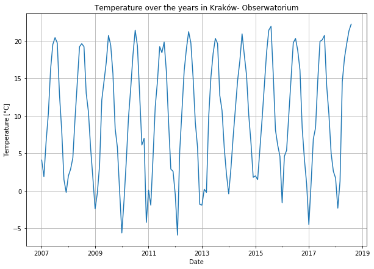

```python
plot_1.basic_plot(series_Krakow,'plot_Krakow_1.png')
```

The example above creates and shows a line plot of the dataset.

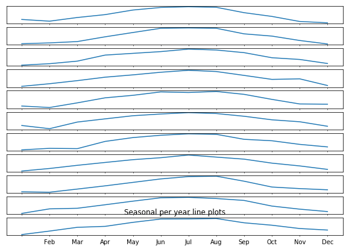

```python
plot_2.seasonal_plot(series_Krakow,'plot_Krakow_2.png')
```

We can confirm the assumption that the seasonality is a yearly cycle by eyeballing line plots of the dataset by year.The example above takes the 11 full years of data as separate groups and creates one line plot for each.This pattern appears the same each year, although at different levels.

[output not shown]

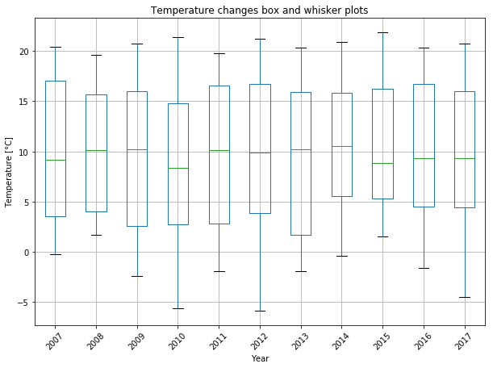

```python
plot_3.time_grouper_plot(series_Krakow,'plot_Krakow_3.png')
```

The example above groups the monthly data by year and get an idea of the spread of observations for each year and how this may be changing, it is called 'Box and whisker plot'. The green segment represent the median value for each year.

Furthermore, we will take a quick look at an autocorrelation plot of the time series. The example below plots the autocorrelation for the number of lags equal to 36.

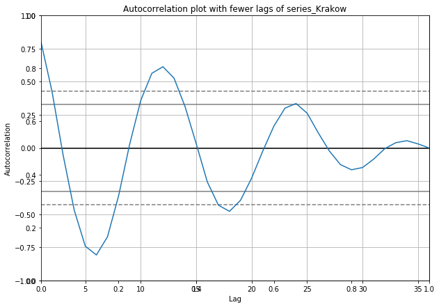

```python
autocorrelation.autocorrelation_plot_function(series_Krakow, 'autocorrelation_plot.png')
```

In the next part we will develop ARIMA model (as described into the introduction). However, there should be provided stationary time series. Fortunately we can make it stationary by differencing the series and using a statistical test (Dickey-Fuller test) to confirm that the result is stationary. Mentioned test is a unit root test, which means that it determines how strongly a time series is defined by a trend.  
It uses an autoregressive model and optimizes an information criterion across multiple different lag values.  
**Null Hypothesis (H0):**  
If failed to be rejected, it suggests the time series has a unit root, meaning it is non-stationary. It has some time dependent structure.  
**Alternate Hypothesis (H1):**  
The null hypothesis is rejected; it suggests the time series does not have a unit root, meaning it is stationary. It does not have time-dependent structure.

```
ADF Statistic: -3.729377
p-value: 0.003718
Critical Values:
	1%: -3.488
	5%: -2.887
	10%: -2.580
```

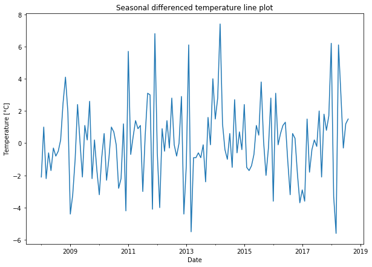

```python
Dickey_test.Dickey_Fuller_test(series_Krakow, 'stationary_data_Krakow.csv', 'Dickey_Fuller_plot.png')
```

It is high time to interpret the p-value from the test. As long as p-value ⩽ 0.05 we are allowed to reject the null hypothesis (H0),moreover, the data does not have a unit root and is stationary. Further, the more negative the ADF statistic is, the more likely we are to reject the null hypothesis.The ADF value of -3.73 is less than the value of -3.488 at 1%. This suggests that we can reject the null hypothesis with a significance level of less than 1%.  
The example above creates a deseasonalized version of the series and saves it to file *stationary_data_Krakow.csv*.  
The plot does not show any obvious seasonality or trend. It also suggests that no further differencing may be required, and that the *d* parameter may be set to 0.

The next step is to select the lag values for *p* and *q* parameters.  
We will use Autocorrelation Function (ACF) and Partial Autocorrelation Function (PACF) plots. As our dataset we wil take the seasonally differenced *stationary_data_Krakow.csv*.

```python
stationary_series=open_csv.open_file('stationary_data_Krakow.csv')
```

```
count    127.000000
mean       0.071654
std        2.474181
min       -5.600000
25%       -1.450000
50%       -0.100000
75%        1.350000
max        7.400000
Name: -2.0999999046325684, dtype: float64
```

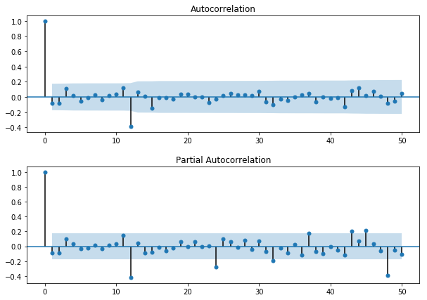

```python
acf_pacf.acf_pacf_function(stationary_series,'ACF_PACF_plot.png')
```

Statistical correlation summarizes the strength of the relationship between two variables. We can calculate the correlation for time series observations with observations with previous time steps, called lags.  
The correlation of the time series observations is calculated with values of the same series at previous times and this is called autocorrelation.  
The second subplot represents partial autocorrelation: *"the partial autocorrelation at lag k is the correlation that results after removing the effect of any correlations due to the terms at shorter lags."* (source: " Partial Autocorrelations, Introductory Time Series with R.")  
Confidence intervals are drawn as a cone.

In the next section, we will search values of *p, d,* and *q* for combinations (skipping those that converge with error), and find the combination that results in the best performance on the test set. We will search all combinations of the following parameters: p(0-6), d(0-2) and q(0-6). If you want to see all the results, uncomment the code below. However, if you are interested only in the best ARIMA parameters, move on to the next paragraph.

```python
"""
import warnings
p_values = range(0, 7)
d_values = range(0, 3)
q_values = range(0, 7)
warnings.filterwarnings("ignore")
best_arima.evaluate_models(series_Krakow, p_values, d_values, q_values)
"""
```

```
'\nimport warnings\np_values = range(0, 7)\nd_values = range(0, 3)\nq_values = range(0, 7)\nwarnings.filterwarnings("ignore")\nbest_arima.evaluate_models(series_Krakow, p_values, d_values, q_values)\n'
```

After checking 147 potential runs of the test, the result is following: Best ARIMA= (6, 0, 2).  
Thus, we will select this model going forward.

```python
print("The lowest RMSE(root mean squared error) for ARIMA(6,0,2): {:0.3f}"\
      .format(evaluate_arima.evaluate_arima_model(series_Krakow.values, (6,0,2))))
```

```
The lowest RMSE(root mean squared error) for ARIMA(6,0,2): 2.604
```

Eventually we will finalizing the model by fitting an ARIMA model on the entire dataset. The model can be saved to file for later use - the whole fit object and the bias one.

```python
monkey_patch.function_to_avoid_bug()
```